# DataLab Cup 4 : Unlearnable Dataset

Shan-Hung Wu & DataLab  
Fall 2021

# Neural Tangent Generalization Attacks (NTGA)

## Platform: [Kaggle CIFAR-10](https://www.kaggle.com/c/datalab-cup4-unlearnable-datasets-cifar-10/overview), [Kaggle Imagenet](https://www.kaggle.com/c/datalab-cup4-unlearnable-datasets-imagenet/overview)

## Overview

In this work, we try to crack the unlearnable dataset which proposed by Neural Tangent Generalization Attacks (NTGA) ICML'21

Authors of NTGA propose the generalization attack, a new direction for poisoning attacks, where an attacker aims to modify training data in order to spoil the training process such that a trained network lacks generalizability. They devise Neural Tangent Generalization Attack (NTGA), a first efficient work enabling clean-label, black-box generalization attacks against Deep Neural Networks.

NTGA declines the generalization ability sharply, i.e. 99% -> 15%, 92% -> 33%, 99% -> 72% on MNIST, CIFAR10 and 2- class ImageNet, respectively.

For detail, please read whole paper [NTGA](http://proceedings.mlr.press/v139/yuan21b.html)

[output not shown]

```python
from __future__ import absolute_import, division, print_function, unicode_literals
import tensorflow as tf
from tensorflow.keras import layers
from tensorflow import keras
from tensorflow.keras.models import Sequential
import tensorflow_addons as tfa
import os

import string
import matplotlib.pyplot as plt
import numpy as np
import pandas as pd
import PIL
import random
import time
from pathlib import Path

from tqdm import tqdm

import re
from IPython import display

BATCH_SIZE = 64
```

```python
gpus = tf.config.experimental.list_physical_devices('GPU')
if gpus:
    try:
        # Restrict TensorFlow to only use the first GPU
        tf.config.experimental.set_visible_devices(gpus[0], 'GPU')

        # Currently, memory growth needs to be the same across GPUs
        for gpu in gpus:
            tf.config.experimental.set_memory_growth(gpu, True)
        logical_gpus = tf.config.experimental.list_logical_devices('GPU')
        print(len(gpus), "Physical GPUs,", len(logical_gpus), "Logical GPUs")
    except RuntimeError as e:
        # Memory growth must be set before GPUs have been initialized
        print(e)
```

```
1 Physical GPUs, 1 Logical GPUs
```

```python
x_train = np.load('./dataset/x_train_cifar10_unlearn.npy')
y_train = np.load('./dataset/y_train_cifar10.npy')
x_val = np.load('./dataset/x_val_cifar10.npy')
y_val = np.load('./dataset/y_val_cifar10.npy')

y_train = np.argmax(y_train, axis=1)
y_val = np.argmax(y_val, axis=1)
```

```python
train_dataset = tf.data.Dataset.from_tensor_slices((x_train, y_train))
batched_dataset = train_dataset.batch(BATCH_SIZE, drop_remainder=True)

val_dataset = tf.data.Dataset.from_tensor_slices((x_val, y_val))
batched_val_dataset = val_dataset.batch(BATCH_SIZE, drop_remainder=True)
```

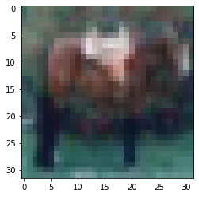

```python
for data in batched_dataset.take(1):
    plt.imshow(data[0][3],cmap='gray')
```

```python
model = Sequential([
  keras.Input(shape=(32, 32, 3)),
  layers.Conv2D(16, 3, padding='same', activation='relu'),
  layers.MaxPooling2D(),
  layers.Conv2D(32, 3, padding='same', activation='relu'),
  layers.MaxPooling2D(),
  layers.Conv2D(64, 3, padding='same', activation='relu'),
  layers.MaxPooling2D(),
  layers.Flatten(),
  layers.Dense(128, activation='relu'),
  layers.Dense(10)
])

model.summary()
```

```
Model: "sequential"
_________________________________________________________________
Layer (type)                 Output Shape              Param #
=================================================================
conv2d (Conv2D)              (None, 32, 32, 16)        448
_________________________________________________________________
max_pooling2d (MaxPooling2D) (None, 16, 16, 16)        0
_________________________________________________________________
conv2d_1 (Conv2D)            (None, 16, 16, 32)        4640
_________________________________________________________________
max_pooling2d_1 (MaxPooling2 (None, 8, 8, 32)          0
_________________________________________________________________
conv2d_2 (Conv2D)            (None, 8, 8, 64)          18496
_________________________________________________________________
max_pooling2d_2 (MaxPooling2 (None, 4, 4, 64)          0
_________________________________________________________________
flatten (Flatten)            (None, 1024)              0
_________________________________________________________________
dense (Dense)                (None, 128)               131200
_________________________________________________________________
dense_1 (Dense)              (None, 10)                1290
=================================================================
Total params: 156,074
Trainable params: 156,074
Non-trainable params: 0
_________________________________________________________________
```

```python
loss_fn = tf.losses.SparseCategoricalCrossentropy(from_logits=True)
optimizer = tf.optimizers.Adam(learning_rate=0.001)
model.compile(optimizer=optimizer, loss=loss_fn, metrics=['acc'])
```

```python
history = model.fit(x=batched_dataset, validation_data=batched_val_dataset, epochs=50)
```

## Property of NTGA

- The following figures show the results of CNN trained on the CIFAR-10 dataset. The figure shows the remarkable result of NTGA, where the training accuracy is ~100%, but test accuracy drops sharply to ~27%, in other word, the model fails to generalize.

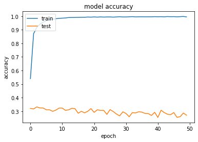

```python
plt.plot(history.history['acc'])
plt.plot(history.history['val_acc'])
plt.title('model accuracy')
plt.ylabel('accuracy')
plt.xlabel('epoch')
plt.legend(['train', 'test'], loc='upper left')
plt.show()
```

# Precautions

## Scoring

- Ranking of **private** leaderboard of competition. **(80%)**
  - team name should be exactly matched with [google sheet](https://docs.google.com/spreadsheets/d/1udCkjpMLY1c8MQ3Jgk5Jc-oOxHlVN0YaoezG5CIKo94/edit#gid=0) or you will get zero in this part
- Report. **(20%)**

The final report should contain following points:

1. Describe what you have done to improve your training accuracy in detail.
2. Explain your code in your notebook for each block.
3. Your training script. We will make sure that your results are reproducible.

## What you should NOT do

- Training on the datasets not provided by us.
- Encoding label information into images.
- Plagiarism. Otherwise, you will get 0 point.

## Hints

- Any model architecture
- Data preprocessing
- Modified training process

## Requirements

- Submit the link of Google Drive containing **report**, **code**, and **your training data**.
  - Name the report/code as DL*comp4*{Your Team number}_report.ipynb
  - Name your training dataset as DL*comp4*{Your Team number}_training_dataset.zip